# MTLD words mapped by semantics

2018-04-03

```r
library(knitr)

opts_chunk$set(echo = T, message = F, warning = F,
               error = F, cache = F, tidy = F)

library(tidyverse)
library(langcog)
library(data.table)
library(feather)
library(broom)

theme_set(theme_classic(base_size = 10))
```

Do low and high kids show different patterns in the semantics of their vocabularies at t1?

Here I took the embeddings from wikipedia for all words produced by the target kids and looked for differences in their semantics. “Low” corresponds to the group of kids who went on to learn relatively fewer words, and “high” corresponds to the group of kids whoe went on to learn relatively more words. These groups were determined using the MTLD measure (see other markdown). There are 51 kids in each group.

My take away is that high kids know more semantically bleached verbs (e.g., “put”, “make”), more conversational words/connectives (e.g. “yes”, “and”, “where”), and more prepositions and pronouns. (Also more number words.)

## Analysis 1: Group level - distribution of words at group level

Get all unique words for two groups at t1.

```r
groups_info <- read_csv("groups_info.csv")
target_types <- read_csv("target_types_delta_450_1150.csv") %>%
  mutate(tbin = fct_recode(tbin,
                           t1 = "low",
                           t2 = "high")) %>%
  mutate(gloss = tolower(gloss))

MIN_KIDS_PRODUCED_WORD <- 3

good_words <- target_types %>%
  count(gloss, target_child_id) %>% # one row a word-kid
  count(gloss) %>%
  filter(nn >= MIN_KIDS_PRODUCED_WORD) # more than n words?

good_kids <- target_types %>%
  filter(gloss %in% good_words$gloss) %>%
  count(target_child_id, tbin) %>% # each row a tbin-kid
  count(target_child_id) %>%
  filter(nn > 1) # two time points?

# get the good words, filtering on kids and words
good_types <- target_types %>%
    filter(gloss %in% good_words$gloss,
           target_child_id %in% good_kids$target_child_id)

# get t1 words only
t1_words <- good_types %>%
  left_join(groups_info %>%
              mutate(target_child_id = as.numeric(target_child_id))) %>%
  filter(tbin == "t1") %>%
  distinct(tbin, delta_resid_group, gloss)
```

Get word embedings from English fasttext. Only 66 words are missing! (5%).

```r
MODEL_PATH <- "wiki.en.vec"
OUTPUT_FILE <- "fast_text_childes_words.feather"

####### Get childes words in the model #########
# model <- fread(
#   MODEL_PATH,
#   header = FALSE,
#   skip = 1,
#   quote = "",
#   encoding = "UTF-8",
#   data.table = TRUE,
#   col.names = c("target_word",
#                 unlist(lapply(2:301, function(x) paste0("V", x)))))
#
# model_filtered <- model[target_word %in% unique(t1_words$gloss)]
# write_feather(model_filtered, OUTPUT_FILE)

model_filtered <- read_feather(OUTPUT_FILE)
```

Get the proportion of kids in each group that knew each word.

```r
prop_from_each_group_said_word_t1 <- good_types %>%
  left_join(groups_info %>%
              mutate(target_child_id = as.numeric(target_child_id)))  %>%
  count(gloss, tbin, delta_resid_group) %>%
  filter(tbin == "t1") %>%
  group_by(gloss) %>%
  mutate(prop = n / dim(groups_info)[1]/2)  %>%
  select(-tbin, -n)
```

Get tsne coordinates and kmeans clusters.

```r
# get tsne coordinates
tsne_out = Rtsne::Rtsne(as.matrix(model_filtered[,-1]))
tsne_dims <- tsne_out$Y %>%
  as.data.frame() %>%
  rename(tsne_X = V1,
         tsne_Y = V2)  %>%
  bind_cols(target_word = model_filtered$target_word) %>%
  select(target_word, everything())
```

```r
N_CLUSTERS <- 25
clusters <- kmeans(scale(tsne_dims[,-1]), N_CLUSTERS)
tsne_dims$cluster = factor(clusters$cluster)
```

### Word clusters (all words)

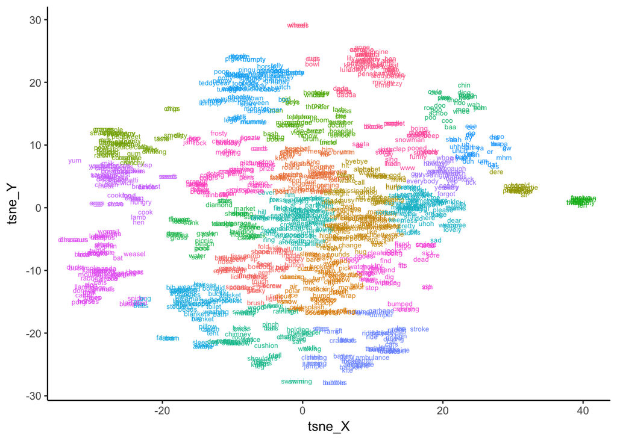

```r
diff_in_props_between_groups <- prop_from_each_group_said_word_t1 %>%
  spread(delta_resid_group, prop) %>%
  mutate(high = ifelse(is.na(high), 0, high),
         low = ifelse(is.na(low), 0, low),
         diff = high - low) %>%
  arrange(-diff) %>%
  left_join(distinct(target_types, gloss)) %>%
  select(gloss,  diff, high, low) %>%
  ungroup()

tsne_dims %>%
  left_join(diff_in_props_between_groups %>%
              select(gloss, diff),
            by = c("target_word" = "gloss")) %>%
    ggplot(aes(x = tsne_X, y = tsne_Y,   group = cluster, color = cluster)) +
  geom_text(aes(label = target_word), size = 2) +
  theme_classic() +
  theme(legend.position = "none")
```

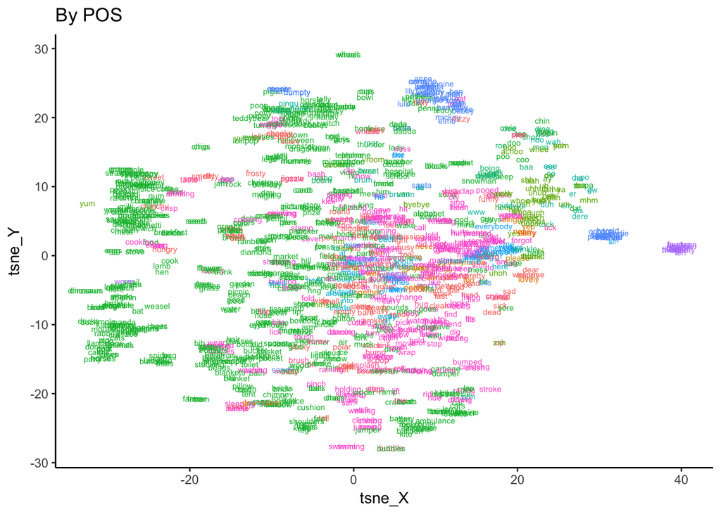

```r
pos2 <- read_csv("molly_pos_gloss_coded.csv") %>%
  select(gloss, stem_gloss, molly_pos)

tsne_dims %>%
  left_join(pos2 %>%
              select(gloss, molly_pos),
            by = c("target_word" = "gloss")) %>%
    ggplot(aes(x = tsne_X, y = tsne_Y,   group = molly_pos, color = molly_pos)) +
  geom_text(aes(label = target_word), size = 2) +
  theme_classic() +
  ggtitle("By POS") +
  theme(legend.position = "none")
```

```r
low_words <- prop_from_each_group_said_word_t1 %>%
  filter(delta_resid_group == "low") %>%
  select(gloss)

low_embeddings <- tsne_dims %>%
  filter(target_word %in% low_words$gloss) %>%
  left_join(prop_from_each_group_said_word_t1 %>%
              filter(delta_resid_group == "low"), by = c("target_word" = "gloss")) %>%
  mutate(group = "low")

high_words <- prop_from_each_group_said_word_t1 %>%
  filter(delta_resid_group == "high") %>%
  select(gloss)

high_embeddings <- tsne_dims %>%
  filter(target_word %in% high_words$gloss) %>%
  left_join(prop_from_each_group_said_word_t1 %>%
              filter(delta_resid_group == "high"), by = c("target_word" = "gloss")) %>%
  mutate(group = "high")

all_group_embeddings <- bind_rows(low_embeddings, high_embeddings)
```

### Proportion of kids in each group that knew each word

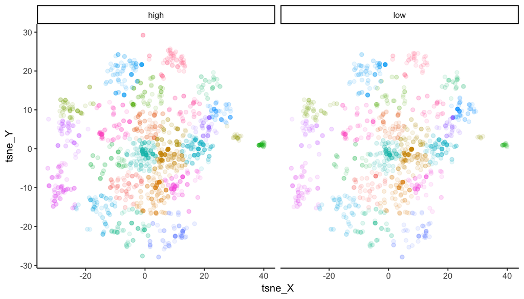

```r
ggplot(all_group_embeddings,
       aes(x = tsne_X, y = tsne_Y,  alpha = prop, color = cluster)) +
  facet_wrap(~ group) +
  geom_point() +
  theme(legend.position = "none")
```

### Words with greatest difference between two groups

Left: Words that high kids said more

Right: words that low kids said more

ALPHA = magnitude of difference

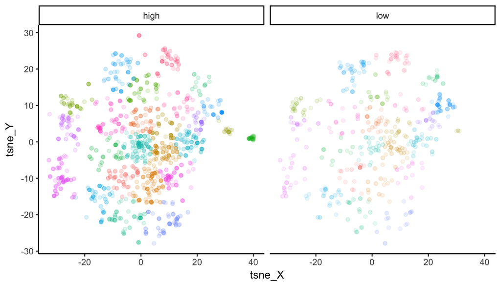

```r
tsne_dims %>%
  left_join(diff_in_props_between_groups %>%
              select(gloss, diff),
            by = c("target_word" = "gloss")) %>%
  mutate(diff_group = ifelse(diff > 0, "high", "low")) %>%
  ggplot(aes(x = tsne_X, y = tsne_Y,  color = cluster, alpha = abs(diff))) +
  facet_wrap(~diff_group) +
  geom_point() +
  theme_classic() +
  theme(legend.position = "none")
```

#### Words that high kids knew more

(diff > .01)

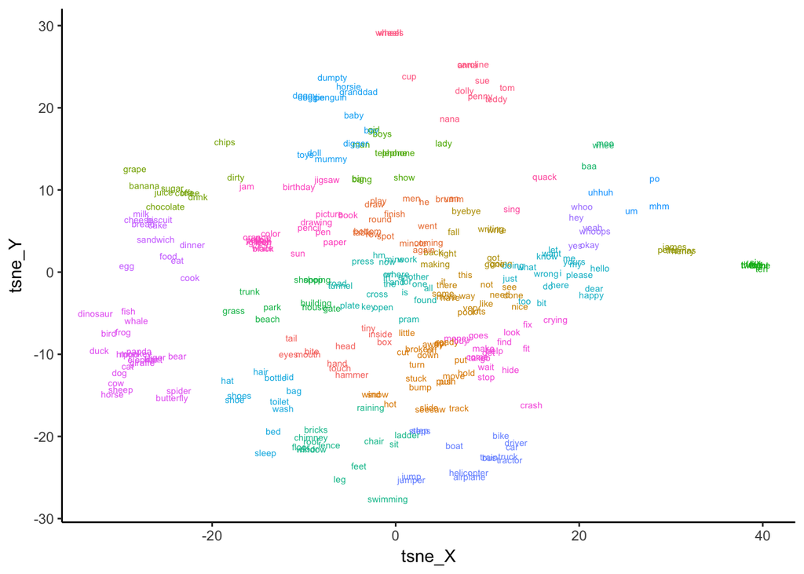

```r
tsne_dims %>%
  left_join(diff_in_props_between_groups %>%
              select(gloss, diff),
            by = c("target_word" = "gloss")) %>%
  filter(diff > .01 ) %>%
  ggplot(aes(x = tsne_X, y = tsne_Y,   group = cluster, color = cluster)) +
  geom_text(aes(label = target_word,), size = 2) +
  theme_classic() +
  theme(legend.position = "none")
```

#### Words that low kids knew more

(all)

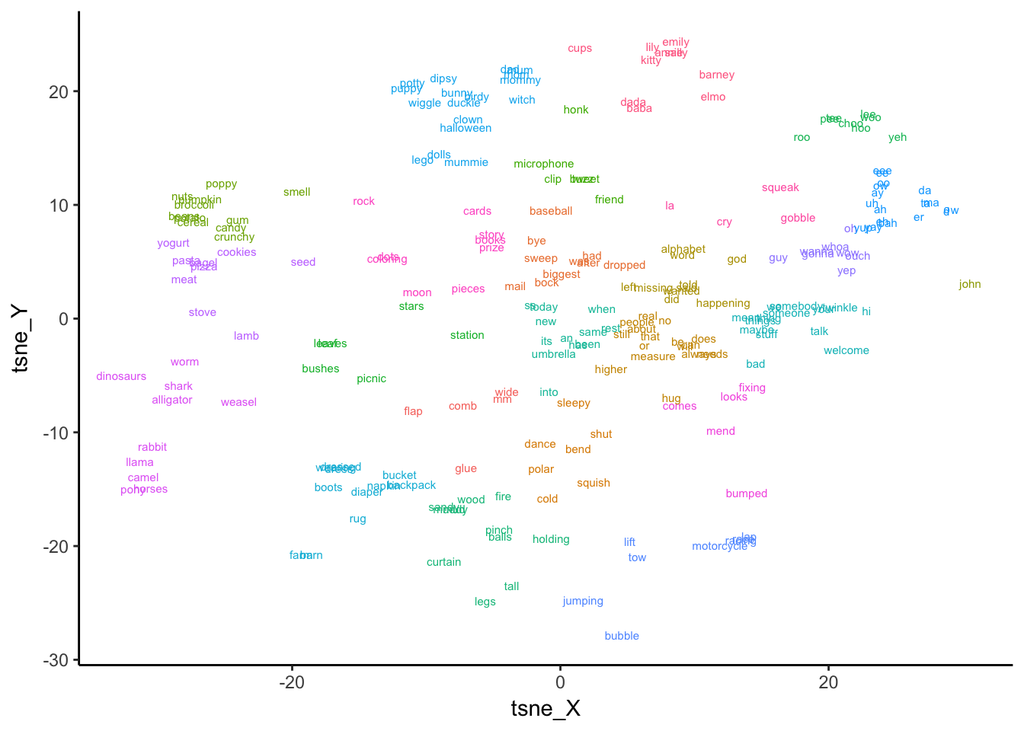

```r
tsne_dims %>%
  left_join(diff_in_props_between_groups %>%
              select(gloss, diff),
            by = c("target_word" = "gloss")) %>%
  filter(diff < 0 ) %>%
    ggplot(aes(x = tsne_X, y = tsne_Y,   group = cluster, color = cluster)) +
  geom_text(aes(label = target_word), size = 2) +
  theme_classic() +
  theme(legend.position = "none")
```

#### Concreteness

Does diff correlate with concretess? Look at Brysbaert concrteness norms. Note that ~22% of words are missing in the norms.

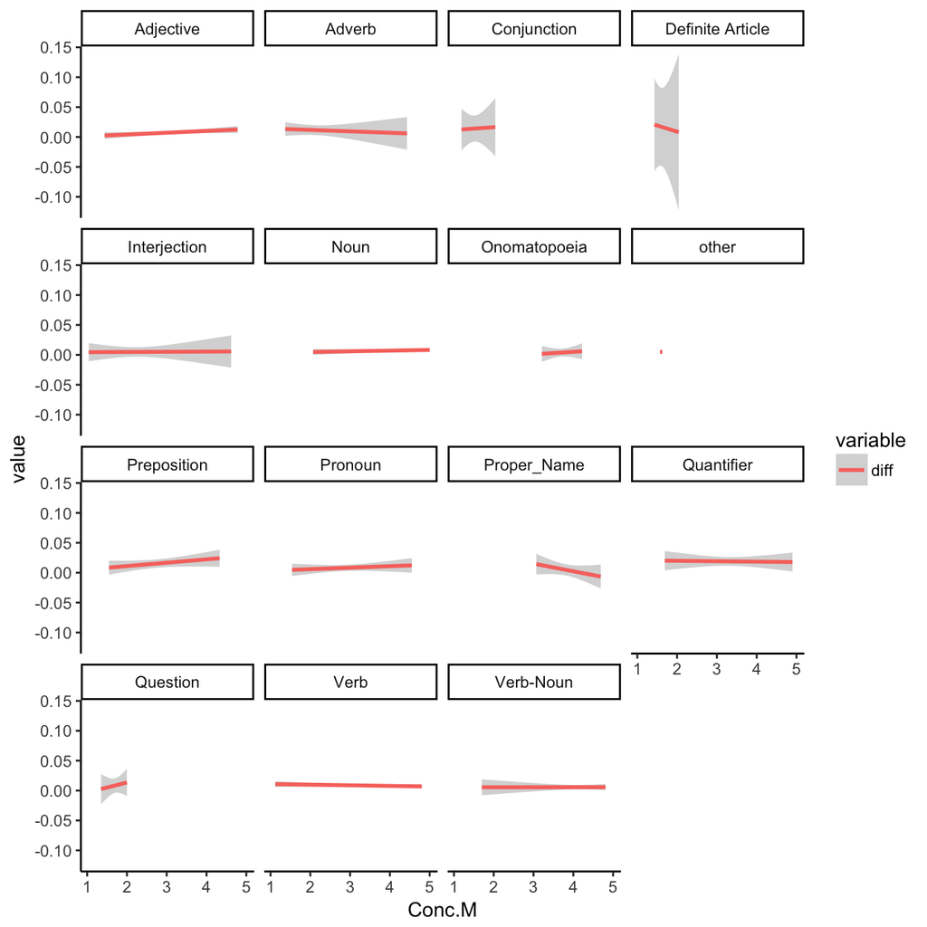

```r
brysbaert <- read_csv("/Users/mollylewis/Documents/research/Projects/ref_complex/corpus/brysbaert_database/brysbaert_corpus.csv") %>%
  select(Word, Conc.M)

lemmas <- read_csv("form-lemma-en-conllu.csv") %>%
  mutate(form = tolower(form),
         lemma = tolower(lemma)) %>%
  distinct(lemma, .keep_all = T)

#diff_in_props_between_groups %>%
#  left_join(pos_tagged) %>%
#  mutate(molly_pos = as.factor(molly_pos)) %>%
#  arrange(molly_pos) %>%
#  write_csv("molly_pos_gloss.csv")

diffs_with_concreteness <- diff_in_props_between_groups %>%
  left_join(lemmas, by = c("gloss" = "form")) %>%
  mutate(lemma = ifelse(is.na(lemma), gloss, lemma)) %>%
  left_join(brysbaert, c("lemma" = "Word")) %>%
  left_join(pos2) %>%
  mutate(molly_pos = as.factor(molly_pos))

diffs_with_concreteness %>%
  select(2:5,6, 8) %>%
  gather("variable", "value", c(-4:-6)) %>%
  filter(variable == "diff") %>%
 ggplot(aes(x =  Conc.M, y = value,
           color = variable, group = variable)) +
    facet_wrap(~molly_pos) +
  #geom_point() +
  geom_smooth(method = "lm") +
  theme_classic()
```

No evidence consitent with idea that difference varies as a function of concreteness.

## Analysis 2: Kid level

### Mean of each kid’s vocabulary (centroid)

```r
good_types_t1 <- good_types %>%
  left_join(groups_info %>%
              mutate(target_child_id = as.numeric(target_child_id))) %>%
  filter(tbin == "t1") %>%
  left_join(pos2)

good_types_t2 <- good_types %>%
  left_join(groups_info %>%
              mutate(target_child_id = as.numeric(target_child_id))) %>%
  filter(tbin == "t2") %>%
  left_join(pos2)

group_ids <-  good_types_t1 %>%
  distinct(target_child_name,
         collection_name,
         corpus_name ,
         delta_resid_group)
```

```r
get_kid_vocab_centroid <- function(target_child_name,
                                 collection_name,
                                 corpus_name,
                                 df,
                                 model){
  x <- collection_name
  y <- corpus_name
  z = target_child_name
  current_df <- df %>%
    filter(collection_name == x,
           corpus_name == y,
           target_child_name == z)

  centroid <- model %>%
    filter(target_word %in% current_df$gloss) %>%
    select(-target_word) %>%
    colSums(.) %>%
    t() %>%
    data.frame() %>%
    mutate(collection_name = collection_name,
           corpus_name = corpus_name,
           target_child_name = target_child_name)

  centroid
}

centroids <- good_types_t1 %>%
  distinct(target_child_name,
         collection_name,
         corpus_name) %>%
    mutate_all(as.character()) %>%
    as.list() %>%
    pmap_df(get_kid_vocab_centroid,
              good_types_t1,
              model_filtered)

tsne_out <- tsne::tsne(as.matrix(centroids[,-301:-303]))
tsne_dims <- tsne_out %>%
  as.data.frame() %>%
  rename(tsne_X = V1,
         tsne_Y = V2)  %>%
  bind_cols(target_child_name = group_ids$target_child_name,
           delta_resid_group = group_ids$delta_resid_group) %>%
  select(target_child_name, delta_resid_group, everything())

tsne_dims %>%
  ggplot(aes(x = tsne_X, y = tsne_Y,
               group = delta_resid_group, color = delta_resid_group)) +
  geom_point() +
  geom_density_2d() +
  theme_classic() +
  theme(legend.position = "none")
```

[output not shown]

### Variance of each kid’s vocabulary

#### Pairwise word distance

```r
# read in raw models from feather
get_model_data2 <- function(target_child_name,
                      collection_name,
                      corpus_name,  df, molly_pos, model){

  x <- collection_name
  y <- corpus_name
  z <- target_child_name
  g <- molly_pos

  current_df <- df %>%
    filter(collection_name == x,
           corpus_name == y,
           target_child_name == z,
           molly_pos == g)

  model_data <- model %>%
    filter(target_word %in% current_df$gloss)

  model_data

}

get_pairwise_dist_beween_words <- function(d){
  model_matrix <- d %>%
    select(-1) %>%
    as.matrix()

  word_word_dists <- philentropy::distance(model_matrix,
                           method = "cosine")

  data.frame(mean_word_dist = mean(word_word_dists, na.rm = T),
             median_word_dist = median(word_word_dists, na.rm = T),
             sd_word_dist = sd(as.vector(word_word_dists)),
             nwords = dim(model_matrix)[1])
}

# wrapper function
get_pairwise_dists_from_raw_model_data <- function(target_child_name,
                                              collection_name,
                                              corpus_name,
                                              molly_pos,
                                              df,
                                              model){
  #print(paste0("====== ", target_child_name, " ======"))

  d <- get_model_data2(target_child_name,
                      collection_name,
                      corpus_name, df, molly_pos, model)

  out <- get_pairwise_dist_beween_words(d) %>%
          mutate(target_child_name = target_child_name,
                 collection_name = collection_name,
                 corpus_name = corpus_name,
                 pos = molly_pos) %>%
          select(target_child_name, collection_name,
                 corpus_name, pos, everything())
  out
}

good_types_t1_pos <- good_types_t1 %>%
    left_join(pos2) %>%
    filter(molly_pos %in% c("Verb", "Noun", "Verb-Noun", "Adjective")) %>%
    #filter(!(molly_pos %in% c("Interjection", "Proper_Name", "other", "Onomatopoeia", "Conjunctions", "Quantifier", "Pronoun", "Preposition", "Question", "Definite Article", "Adverbs"))) %>%
    mutate(molly_pos = "content")

mean_pairwise_dists <- good_types_t1_pos %>%
  filter(gloss %in% model_filtered$target_word) %>%
  distinct(target_child_name,
          collection_name,
          corpus_name,
          molly_pos) %>%
    mutate_all(as.character()) %>%
    as.list() %>%
    pmap_df(get_pairwise_dists_from_raw_model_data,
            good_types_t1_pos, model_filtered)

pairwise_df <- mean_pairwise_dists %>%
    left_join(group_ids) %>%
    mutate_if(is.character, as.factor)

tidy(glm(delta_resid_group ~ log(sd_word_dist) + mean_word_dist ,
              family = "binomial", d = pairwise_df)) %>%
  kable()
```

| term | estimate | std.error | statistic | p.value |
| --- | --- | --- | --- | --- |
| (Intercept) | 12.079068 | 4.540922 | 2.660048 | 0.0078130 |
| log(sd_word_dist) | 4.110651 | 1.430687 | 2.873200 | 0.0040634 |
| mean_word_dist | -17.315558 | 7.380274 | -2.346195 | 0.0189662 |